# Data Science in a Box Lab 5

Alex Lindquist, Nate Smullen, Wynter Malone, Yadhira Garcia

10/17/2022

##Load Packages

```r
library(tidyverse)
library(dsbox)
library(here)
library(janitor)
```

##Alaska

```r
dn_ak <- dennys %>%
  filter(state == "AK")
nrow(dn_ak)
```

```
[1] 3
```

There are 3 Denny’s in Alaska.

```r
lq_ak <- laquinta %>%
  filter(state == "AK")
nrow(lq_ak)
```

```
[1] 2
```

There are 2 LaQuintas in Alaska.

```r
dn_lq_ak <- full_join(dn_ak, lq_ak, by = "state")
dn_lq_ak
```

| address.x | city.x | state | zip.x | longitude.x | latitude.x | address.y | city.y | zip.y | longitude.y | latitude.y |
| --- | --- | --- | --- | --- | --- | --- | --- | --- | --- | --- |
| 2900 Denali | Anchorage | AK | 99503 | -149.8767 | 61.1953 | 3501 Minnesota Dr. | \nAnchorage | 99503 | -149.9119 | 61.18843 |
| 2900 Denali | Anchorage | AK | 99503 | -149.8767 | 61.1953 | 4920 Dale Rd | \nFairbanks | 99709 | -147.8660 | 64.82426 |
| 3850 Debarr Road | Anchorage | AK | 99508 | -149.8090 | 61.2097 | 3501 Minnesota Dr. | \nAnchorage | 99503 | -149.9119 | 61.18843 |
| 3850 Debarr Road | Anchorage | AK | 99508 | -149.8090 | 61.2097 | 4920 Dale Rd | \nFairbanks | 99709 | -147.8660 | 64.82426 |
| 1929 Airport Way | Fairbanks | AK | 99701 | -147.7600 | 64.8366 | 3501 Minnesota Dr. | \nAnchorage | 99503 | -149.9119 | 61.18843 |
| 1929 Airport Way | Fairbanks | AK | 99701 | -147.7600 | 64.8366 | 4920 Dale Rd | \nFairbanks | 99709 | -147.8660 | 64.82426 |

There are 6 observations in this joined dataframe, as there are 3 Denny’s and 2 LaQuintas, so there are 6 total combinations of the two. The Denny’s are represented with .x variable names whereas the LaQuintas are represented with the .y variable names.

```r
haversine <- function(long1, lat1, long2, lat2, round = 3) {
  # convert to radians
  long1 = long1 * pi / 180
  lat1  = lat1  * pi / 180
  long2 = long2 * pi / 180
  lat2  = lat2  * pi / 180

  R = 6371 # Earth mean radius in km

  a = sin((lat2 - lat1)/2)^2 + cos(lat1) * cos(lat2) * sin((long2 - long1)/2)^2
  d = R * 2 * asin(sqrt(a))

  return( round(d,round) ) # distance in km
}
```

```r
dn_lq_ak <- dn_lq_ak %>% mutate(distance = haversine(longitude.x, latitude.x,
                                                     longitude.y, latitude.y))
```

```r
dn_lq_ak_mindist <- dn_lq_ak %>%
  group_by(address.x) %>%
  summarise(closest = min(distance))
```

```r
summary(dn_lq_ak_mindist)
```

```
  address.x            closest
 Length:3           Min.   :2.035
 Class :character   1st Qu.:3.616
 Mode  :character   Median :5.197
                    Mean   :4.410
                    3rd Qu.:5.598
                    Max.   :5.998
```

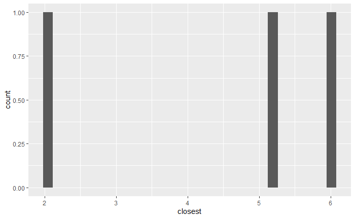

```r
dn_lq_ak_mindist %>% ggplot(aes(x=closest)) + geom_histogram()
```

There are only 3 data points, so it is difficult to describe the distribution. All of the Denny’s have a LaQuinta within 6km.

##North Carolina

```r
dn_nc <- dennys %>%
  filter(state == "NC")
nrow(dn_nc)
```

```
[1] 28
```

There are 28 Denny’s in North Carolina.

```r
lq_nc <- laquinta %>%
  filter(state == "NC")
nrow(lq_nc)
```

```
[1] 12
```

There are 12 LaQuintas in North Carolina.

```r
dn_lq_nc <- full_join(dn_nc, lq_nc, by = "state")
dn_lq_nc
```

| address.x | city.x | state | zip.x | longitude.x | latitude.x | address.y | city.y | zip.y | longitude.y | latitude.y |
| --- | --- | --- | --- | --- | --- | --- | --- | --- | --- | --- |
| 1 Regent Park Boulevard | Asheville | NC | 28806 | -82.5820 | 35.5888 | 165 Hwy 105 Extension | \nBoone | 28607 | -81.66881 | 36.21550 |
| 1 Regent Park Boulevard | Asheville | NC | 28806 | -82.5820 | 35.5888 | 3127 Sloan Dr | \nCharlotte | 28208 | -80.92088 | 35.24087 |
| 1 Regent Park Boulevard | Asheville | NC | 28806 | -82.5820 | 35.5888 | 4900 South Tryon St | \nCharlotte | 28217 | -80.89117 | 35.17895 |
| 1 Regent Park Boulevard | Asheville | NC | 28806 | -82.5820 | 35.5888 | 4414 Durham Chapel Hill Blvd | \nDurham | 27707 | -78.97218 | 35.96460 |
| 1 Regent Park Boulevard | Asheville | NC | 28806 | -82.5820 | 35.5888 | 1910 Westpark Dr | \nDurham | 27713 | -78.89145 | 35.90796 |
| 1 Regent Park Boulevard | Asheville | NC | 28806 | -82.5820 | 35.5888 | 1201 Lanada Rd | \nGreensboro | 27407 | -79.89346 | 36.05371 |
| 1 Regent Park Boulevard | Asheville | NC | 28806 | -82.5820 | 35.5888 | 1607 Fairgrove Church Rd | \nConover | 28613 | -81.26184 | 35.70027 |
| 1 Regent Park Boulevard | Asheville | NC | 28806 | -82.5820 | 35.5888 | 191 Crescent Commons | \nCary | 27518 | -78.78415 | 35.73580 |
| 1 Regent Park Boulevard | Asheville | NC | 28806 | -82.5820 | 35.5888 | 2211 Summit Park Ln | \nRaleigh | 27612 | -78.67605 | 35.83362 |
| 1 Regent Park Boulevard | Asheville | NC | 28806 | -82.5820 | 35.5888 | 1001 Aerial Center Pkwy | \nMorrisville | 27560 | -78.81659 | 35.85856 |

[output cut: 326 more lines]

There are 336 observations in this joined dataframe, as there are 28 Denny’s and 12 LaQuintas. The Denny’s are represented with .x variable names whereas the LaQuintas are represented with the .y variable names.

```r
dn_lq_nc <- dn_lq_nc %>% mutate(distance = haversine(longitude.x, latitude.x,
                                                     longitude.y, latitude.y))
```

```r
dn_lq_nc_mindist <- dn_lq_nc %>%
  group_by(address.x) %>%
  summarise(closest = min(distance))
```

```r
summary(dn_lq_nc_mindist)
```

```
  address.x            closest
 Length:28          Min.   :  1.779
 Class :character   1st Qu.: 22.388
 Mode  :character   Median : 53.456
                    Mean   : 65.444
                    3rd Qu.: 93.985
                    Max.   :187.935
```

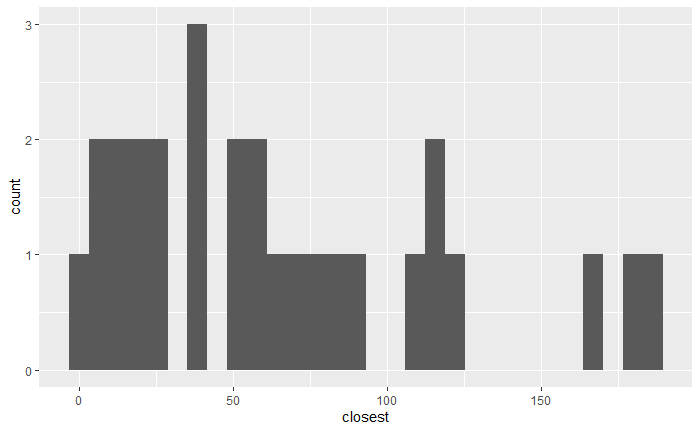

```r
dn_lq_nc_mindist %>% ggplot(aes(x=closest)) + geom_histogram()
```

The distribution for the closest LaQuinta to each Denny’s is skewed right.

##Texas

```r
dn_tx <- dennys %>%
  filter(state == "TX")
nrow(dn_tx)
```

```
[1] 200
```

There are 200 Denny’s in Texas.

```r
lq_tx <- laquinta %>%
  filter(state == "TX")
nrow(lq_tx)
```

```
[1] 237
```

There are 237 LaQuintas in Texas.

```r
dn_lq_tx <- full_join(dn_tx, lq_tx, by = "state")
dn_lq_tx
```

| address.x | city.x | state | zip.x | longitude.x | latitude.x | address.y | city.y | zip.y | longitude.y | latitude.y |
| --- | --- | --- | --- | --- | --- | --- | --- | --- | --- | --- |
| 120 East I-20 | Abilene | TX | 79601 | -99.6435 | 32.4394 | 3018 CatClaw Dr | \nAbilene | 79606 | -99.77877 | 32.41349 |
| 120 East I-20 | Abilene | TX | 79601 | -99.6435 | 32.4394 | 3501 West Lake Rd | \nAbilene | 79601 | -99.72269 | 32.49136 |
| 120 East I-20 | Abilene | TX | 79601 | -99.6435 | 32.4394 | 14925 Landmark Blvd | \nAddison | 75254 | -96.82874 | 32.95164 |
| 120 East I-20 | Abilene | TX | 79601 | -99.6435 | 32.4394 | 909 East Frontage Rd | \nAlamo | 78516 | -98.11925 | 26.18997 |
| 120 East I-20 | Abilene | TX | 79601 | -99.6435 | 32.4394 | 2400 East Main St | \nAlice | 78332 | -98.04351 | 27.76425 |
| 120 East I-20 | Abilene | TX | 79601 | -99.6435 | 32.4394 | 1220 North Central Expressway | \nAllen | 75013 | -96.66739 | 33.11674 |
| 120 East I-20 | Abilene | TX | 79601 | -99.6435 | 32.4394 | 1165 Hwy 67W | \nAlvarado | 76009 | -97.22377 | 32.41490 |
| 120 East I-20 | Abilene | TX | 79601 | -99.6435 | 32.4394 | 880 South Loop 35 | \nAlvin | 77511 | -95.23011 | 29.41755 |
| 120 East I-20 | Abilene | TX | 79601 | -99.6435 | 32.4394 | 1708 Interstate 40 East | \nAmarillo | 79103 | -101.81877 | 35.19200 |
| 120 East I-20 | Abilene | TX | 79601 | -99.6435 | 32.4394 | 9305 East Interstate 40 | \nAmarillo | 79118 | -101.73149 | 35.19372 |

[output cut: 990 more lines]

There are 47,400 observations in this joined dataframe, as there are 200 Denny’s and 237 LaQuintas. The Denny’s are represented with .x variable names whereas the LaQuintas are represented with the .y variable names.

```r
dn_lq_tx <- dn_lq_tx %>% mutate(distance = haversine(longitude.x, latitude.x,
                                                     longitude.y, latitude.y))
```

```r
dn_lq_tx_mindist <- dn_lq_tx %>%
  group_by(address.x) %>%
  summarise(closest = min(distance))
```

```r
summary(dn_lq_tx_mindist)
```

```
  address.x            closest
 Length:200         Min.   : 0.0160
 Class :character   1st Qu.: 0.7305
 Mode  :character   Median : 3.3715
                    Mean   : 5.7918
                    3rd Qu.: 6.6303
                    Max.   :60.5820
```

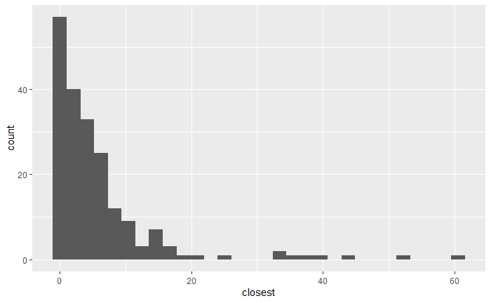

```r
dn_lq_tx_mindist %>% ggplot(aes(x=closest)) + geom_histogram()
```

The distribution for the closest LaQuinta to each Denny’s is skewed right, with a majority of the Denny’s having a LaQuinta within 10 kilometers.

##California

```r
dn_ca <- dennys %>%
  filter(state == "CA")
nrow(dn_ca)
```

```
[1] 403
```

There are 403 Denny’s in California.

```r
lq_ca <- laquinta %>%
  filter(state == "CA")
nrow(lq_ca)
```

```
[1] 56
```

There are 56 LaQuintas in California.

```r
dn_lq_ca <- full_join(dn_ca, lq_ca, by = "state")
dn_lq_ca
```

| address.x | city.x | state | zip.x | longitude.x | latitude.x | address.y | city.y | zip.y | longitude.y | latitude.y |
| --- | --- | --- | --- | --- | --- | --- | --- | --- | --- | --- |
| 14240 Us Highway 395 | Adelanto | CA | 92301 | -117.3996 | 34.5091 | 1752 Clementine St | \nAnaheim | 92802 | -117.9099 | 33.80434 |
| 14240 Us Highway 395 | Adelanto | CA | 92301 | -117.3996 | 34.5091 | 8858 Spectrum Park Way | \nBakersfield | 93308 | -119.0763 | 35.44045 |
| 14240 Us Highway 395 | Adelanto | CA | 92301 | -117.3996 | 34.5091 | 3232 Riverside Dr | \nBakersfield | 93308 | -119.0424 | 35.38327 |
| 14240 Us Highway 395 | Adelanto | CA | 92301 | -117.3996 | 34.5091 | 920 University Ave | \nBerkeley | 94710 | -122.2956 | 37.86838 |
| 14240 Us Highway 395 | Adelanto | CA | 92301 | -117.3996 | 34.5091 | 3 Centerpointe Dr | \nLa Palma | 90623 | -118.0314 | 33.86041 |
| 14240 Us Highway 395 | Adelanto | CA | 92301 | -117.3996 | 34.5091 | 1771 Research Park Dr | \nDavis | 95618 | -121.7312 | 38.54085 |
| 14240 Us Highway 395 | Adelanto | CA | 92301 | -117.3996 | 34.5091 | 6275 Dublin Blvd | \nDublin | 94568 | -121.9079 | 37.70620 |
| 14240 Us Highway 395 | Adelanto | CA | 92301 | -117.3996 | 34.5091 | 316 Pittman Road | \nFairfield | 94534 | -122.1276 | 38.21947 |
| 14240 Us Highway 395 | Adelanto | CA | 92301 | -117.3996 | 34.5091 | 190 N. 10th Street | \nFowler | 93625 | -119.6839 | 36.62792 |
| 14240 Us Highway 395 | Adelanto | CA | 92301 | -117.3996 | 34.5091 | 46200 Landing Pkwy | \nFremont | 94538 | -121.9449 | 37.48886 |

[output cut: 990 more lines]

There are 22,568 observations in this joined dataframe, as there are 403 Denny’s and 56 LaQuintas. The Denny’s are represented with .x variable names whereas the LaQuintas are represented with the .y variable names.

```r
dn_lq_ca <- dn_lq_ca %>% mutate(distance = haversine(longitude.x, latitude.x,
                                                     longitude.y, latitude.y))
```

```r
dn_lq_ca_mindist <- dn_lq_ca %>%
  group_by(address.x) %>%
  summarise(closest = min(distance))
```

```r
summary(dn_lq_ca_mindist)
```

```
  address.x            closest
 Length:403         Min.   :  0.016
 Class :character   1st Qu.:  5.767
 Mode  :character   Median : 11.897
                    Mean   : 22.083
                    3rd Qu.: 22.796
                    Max.   :253.462
```

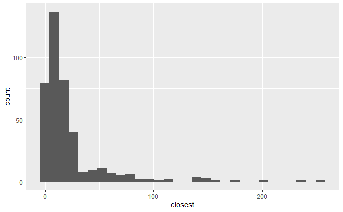

```r
dn_lq_ca_mindist %>% ggplot(aes(x=closest)) + geom_histogram()
```

The distribution for the closest LaQuinta to each Denny’s is skewed right, with a majority of the Denny’s having a LaQuinta within 25 kilometers.

```r
file = here("data_raw","FastFoodRestaurants.csv")
ffr <- read_csv(file)
```

```r
mcd_nc <- ffr %>%
  rename(state = province) %>%
  filter(state == "NC", name == "McDonald's") %>%
  slice_sample(n=28)
```

```r
mcd_lq_nc <- full_join(mcd_nc, lq_nc, by = "state")
mcd_lq_nc
```

| address.x | city.x | country | keys | latitude.x | longitude.x | name | postalCode | state | websites | address.y | city.y | zip | longitude.y | latitude.y |
| --- | --- | --- | --- | --- | --- | --- | --- | --- | --- | --- | --- | --- | --- | --- |
| 508 Renfro St | Mount Airy | US | us/nc/mountairy/508renfrost/-1161002137 | 36.50410 | -80.60660 | McDonald's | 27030 | NC | http://mcdonalds.com,http://www.mcdonalds.com/?cid=RF:YXT_FM:TP::Yext:Referral | 165 Hwy 105 Extension | \nBoone | 28607 | -81.66881 | 36.21550 |
| 508 Renfro St | Mount Airy | US | us/nc/mountairy/508renfrost/-1161002137 | 36.50410 | -80.60660 | McDonald's | 27030 | NC | http://mcdonalds.com,http://www.mcdonalds.com/?cid=RF:YXT_FM:TP::Yext:Referral | 3127 Sloan Dr | \nCharlotte | 28208 | -80.92088 | 35.24087 |
| 508 Renfro St | Mount Airy | US | us/nc/mountairy/508renfrost/-1161002137 | 36.50410 | -80.60660 | McDonald's | 27030 | NC | http://mcdonalds.com,http://www.mcdonalds.com/?cid=RF:YXT_FM:TP::Yext:Referral | 4900 South Tryon St | \nCharlotte | 28217 | -80.89117 | 35.17895 |
| 508 Renfro St | Mount Airy | US | us/nc/mountairy/508renfrost/-1161002137 | 36.50410 | -80.60660 | McDonald's | 27030 | NC | http://mcdonalds.com,http://www.mcdonalds.com/?cid=RF:YXT_FM:TP::Yext:Referral | 4414 Durham Chapel Hill Blvd | \nDurham | 27707 | -78.97218 | 35.96460 |
| 508 Renfro St | Mount Airy | US | us/nc/mountairy/508renfrost/-1161002137 | 36.50410 | -80.60660 | McDonald's | 27030 | NC | http://mcdonalds.com,http://www.mcdonalds.com/?cid=RF:YXT_FM:TP::Yext:Referral | 1910 Westpark Dr | \nDurham | 27713 | -78.89145 | 35.90796 |
| 508 Renfro St | Mount Airy | US | us/nc/mountairy/508renfrost/-1161002137 | 36.50410 | -80.60660 | McDonald's | 27030 | NC | http://mcdonalds.com,http://www.mcdonalds.com/?cid=RF:YXT_FM:TP::Yext:Referral | 1201 Lanada Rd | \nGreensboro | 27407 | -79.89346 | 36.05371 |
| 508 Renfro St | Mount Airy | US | us/nc/mountairy/508renfrost/-1161002137 | 36.50410 | -80.60660 | McDonald's | 27030 | NC | http://mcdonalds.com,http://www.mcdonalds.com/?cid=RF:YXT_FM:TP::Yext:Referral | 1607 Fairgrove Church Rd | \nConover | 28613 | -81.26184 | 35.70027 |
| 508 Renfro St | Mount Airy | US | us/nc/mountairy/508renfrost/-1161002137 | 36.50410 | -80.60660 | McDonald's | 27030 | NC | http://mcdonalds.com,http://www.mcdonalds.com/?cid=RF:YXT_FM:TP::Yext:Referral | 191 Crescent Commons | \nCary | 27518 | -78.78415 | 35.73580 |
| 508 Renfro St | Mount Airy | US | us/nc/mountairy/508renfrost/-1161002137 | 36.50410 | -80.60660 | McDonald's | 27030 | NC | http://mcdonalds.com,http://www.mcdonalds.com/?cid=RF:YXT_FM:TP::Yext:Referral | 2211 Summit Park Ln | \nRaleigh | 27612 | -78.67605 | 35.83362 |
| 508 Renfro St | Mount Airy | US | us/nc/mountairy/508renfrost/-1161002137 | 36.50410 | -80.60660 | McDonald's | 27030 | NC | http://mcdonalds.com,http://www.mcdonalds.com/?cid=RF:YXT_FM:TP::Yext:Referral | 1001 Aerial Center Pkwy | \nMorrisville | 27560 | -78.81659 | 35.85856 |

[output cut: 326 more lines]

```r
mcd_lq_nc <- mcd_lq_nc %>% mutate(distance = haversine(longitude.x, latitude.x,
                                                     longitude.y, latitude.y))
```

```r
mcd_lq_nc_mindist <- mcd_lq_nc %>%
  group_by(address.x) %>%
  summarise(closest = min(distance))
```

```r
summary(mcd_lq_nc_mindist)
```

[output not shown]